# Peer Assessment 1

Savir Huitron

15 de noviembre de 2015

## Summary

This is a report from the peer assessment 1, we will use **dplyr** and **tidyr** packages for the data managament and **ggplot2** and **lattice** for the visualizations.

### 1. Loading and preprocessing the data

**1.1 Load the data**

We load the data, I use two datsets in order to accomplish the fifth point.

```r
data <- read.csv("activity.csv")
#data <- read.csv("activity.csv")
```

We can see how is our data, both with the “head” and “tail” commands in **R**.

```r
head(data)
```

```
##   steps       date interval
## 1    NA 2012-10-01        0
## 2    NA 2012-10-01        5
## 3    NA 2012-10-01       10
## 4    NA 2012-10-01       15
## 5    NA 2012-10-01       20
## 6    NA 2012-10-01       25
```

```r
tail(data)
```

```
##       steps       date interval
## 17563    NA 2012-11-30     2330
## 17564    NA 2012-11-30     2335
## 17565    NA 2012-11-30     2340
## 17566    NA 2012-11-30     2345
## 17567    NA 2012-11-30     2350
## 17568    NA 2012-11-30     2355
```

**1.2 Process/transform the data (if necessary) into a format suitable for your analysis**

For this point, I will adjust the data for answering the questions.

### 2. What is the mean total number of steps taken per day?

**2.1 Calculate the total number of steps taken per day**

We use the **dplyr** package for the summarize of the data per day:

```r
steps <- group_by(data, date)
t1 <- summarize(steps, total = sum(steps, na.rm = TRUE))
```

**2.2 Make a histogram of the total number of steps taken each day**

```
## stat_bin: binwidth defaulted to range/30. Use 'binwidth = x' to adjust this.
```

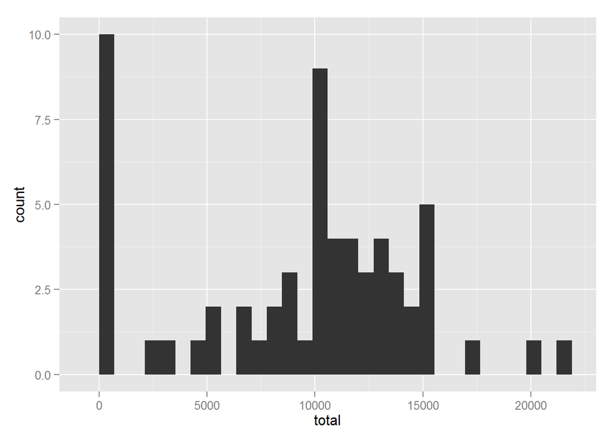

```r
p <- ggplot(t1, aes(total))
p + geom_histogram()
```

**2.3 Calculate and report the mean and median of the total number of steps taken per day**

```r
mn <- mean(t1$total)
md <- median(t1$total)
```

The mean is **9354.2295082** and the median is **10395**

### 3. What is the average daily activity pattern?

**3.1 Make a time series plot (i.e. type = “l”) of the 5-minute interval (x-axis) and the average number of steps taken, averaged across all days (y-axis)**

We use the **dplyr** package for summarize the mean of the intervals.

```r
fv <- group_by(data, interval) %>%
                summarize(new = mean(steps, na.rm = TRUE))
```

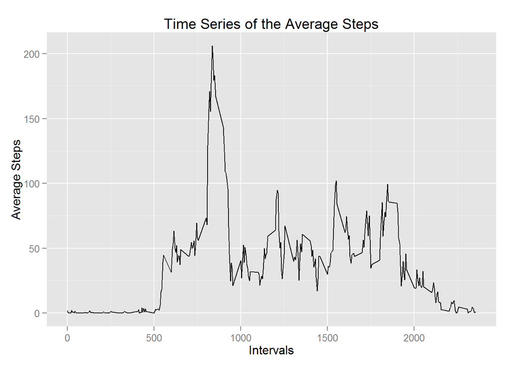

```r
l <- ggplot(fv, aes(x = interval, y = new)) %>%
    + geom_line()  %>%
    + labs(title = "Time Series of the Average Steps", x = "Intervals", y = "Average Steps")
```

**3.2 Which 5-minute interval, on average across all the days in the dataset, contains the maximum number of steps?**

```r
h <- max(fv$new)

h1 <- filter(fv, new == h)
```

As we can see the max average steps is **206.1698113** in the interval **835**

### 4. Imputing missing values

**4.1 Calculate and report the total number of missing values in the dataset (i.e. the total number of rows with NAs)**

```r
na_count <- sum(is.na(data$steps))
```

The number of NA’S are **2304**

**4.2 Devise a strategy for filling in all of the missing values in the dataset. The strategy does not need to be sophisticated. For example, you could use the mean/median for that day, or the mean for that 5-minute interval, etc.**

```r
na_pos <- which(is.na(data$steps))

mean_vec <- rep(mean(data$steps, na.rm=TRUE), times=length(na_pos))
```

The strategy to use is to remplace each NA value by the mean of the steps attribute.

**4.3 Create a new dataset that is equal to the original dataset but with the missing data filled in.**

We replace the NA’s by the means

```r
data[na_pos, "steps"] <- mean_vec
```

We see the new dataset

```r
head(data)
```

```
##     steps       date interval
## 1 37.3826 2012-10-01        0
## 2 37.3826 2012-10-01        5
## 3 37.3826 2012-10-01       10
## 4 37.3826 2012-10-01       15
## 5 37.3826 2012-10-01       20
## 6 37.3826 2012-10-01       25
```

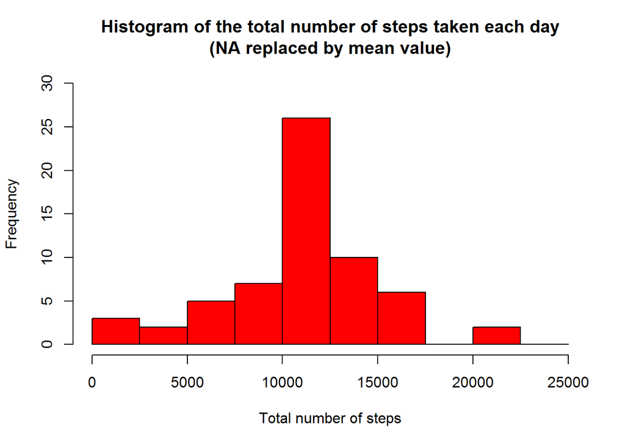

```r
sum_data <- aggregate(data$steps, by=list(data$date), FUN=sum)

# Rename the attributes
names(sum_data) <- c("date", "total")

# Compute the histogram of the total number of steps each day
hist(sum_data$total,
     breaks=seq(from=0, to=25000, by=2500),
     col="red",
     xlab="Total number of steps",
     ylim=c(0, 30),
     main="Histogram of the total number of steps taken each day\n(NA replaced by mean value)")
```

```r
nmn <- mean(sum_data$total)
nm <- median(sum_data$total)
```

### 5. Are there differences in activity patterns between weekdays and weekends?

**5.1 Create a new factor variable in the dataset with two levels  “weekday” and “weekend” indicating whether a given date is a weekday or weekend day.**

```r
data$date <- as.POSIXct(data$date, format="%Y-%m-%d")

data <- data.frame(date=data$date,
                           weekday=tolower(weekdays(data$date)),
                           steps=data$steps,
                           interval=data$interval)

data <- cbind(data,
                      daytype=ifelse(data$weekday == "sábado" |
                                     data$weekday == "domingo", "weekend",
                                     "weekday"))

activity <- data.frame(date=data$date,
                       weekday=data$weekday,
                       daytype=data$daytype,
                       interval=data$interval,
                       steps=data$steps)
```

```r
head(activity)
```

```
##         date weekday daytype interval   steps
## 1 2012-10-01   lunes weekday        0 37.3826
## 2 2012-10-01   lunes weekday        5 37.3826
## 3 2012-10-01   lunes weekday       10 37.3826
## 4 2012-10-01   lunes weekday       15 37.3826
## 5 2012-10-01   lunes weekday       20 37.3826
## 6 2012-10-01   lunes weekday       25 37.3826
```

```r
mean_data <- aggregate(activity$steps,
                       by=list(activity$daytype,
                               activity$weekday, activity$interval), mean)

names(mean_data) <- c("daytype", "weekday", "interval", "mean")
```

```r
head(mean_data)
```

```
##   daytype   weekday interval     mean
## 1 weekend   domingo        0 4.672825
## 2 weekday    jueves        0 9.375844
## 3 weekday     lunes        0 9.418355
## 4 weekday    martes        0 0.000000
## 5 weekday miércoles        0 7.931400
## 6 weekend    sábado        0 4.672825
```

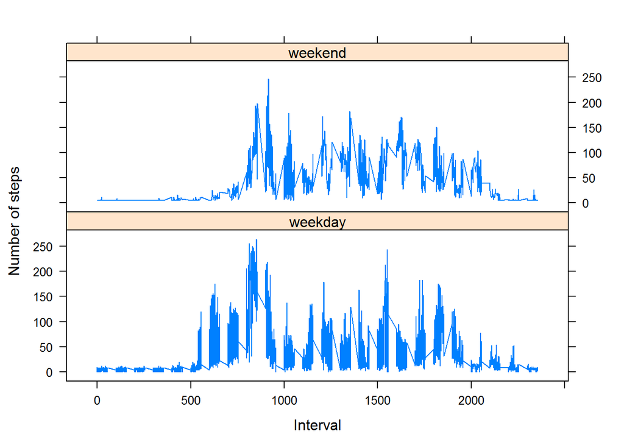

```r
xyplot(mean ~ interval | daytype, mean_data,
       type="l",
       lwd=1,
       xlab="Interval",
       ylab="Number of steps",
       layout=c(1,2))
```